# Project Mercedes-Benz Greener Manufacturing

## Project: Mercedes-Benz Greener Manufacturing

## 1. Import Libraries

```python
import numpy as np
import pandas as pd
import seaborn as sns
import matplotlib.pyplot as plt
%matplotlib inline
plt.style.use('fivethirtyeight')

from sklearn import preprocessing
from sklearn.decomposition import PCA, FastICA
seed =45
from sklearn.linear_model import LinearRegression, LogisticRegression
from sklearn.metrics import mean_squared_error as mse
import sklearn.metrics
from sklearn.linear_model import Ridge
from sklearn import linear_model
from sklearn.tree import DecisionTreeRegressor
from sklearn.neighbors import KNeighborsRegressor
from sklearn.model_selection import KFold, GridSearchCV
from sklearn.svm import SVR
from sklearn.feature_selection import RFE
from statsmodels.stats.outliers_influence import variance_inflation_factor
from sklearn.decomposition import TruncatedSVD
```

## 2. Import train and test dataset

```python
train_df =pd.read_csv("C:/Users/Pinak Ganguly/Desktop/Machine-Learning--Projects-master/Projects/Projects for Submission/Project 1 - Mercedes-Benz Greener Manufacturing/Dataset for the project/train.csv");
test_df =pd.read_csv("C:/Users/Pinak Ganguly/Desktop/Machine-Learning--Projects-master/Projects/Projects for Submission/Project 1 - Mercedes-Benz Greener Manufacturing/Dataset for the project/test.csv");
print('Train dataset shape = ', train_df.shape)
print('Test dataset shape = ',test_df.shape)
```

```
Train dataset shape =  (4209, 378)
Test dataset shape =  (4209, 377)
```

```python
train_df.head()
```

|  | ID | y | X0 | X1 | X2 | X3 | X4 | X5 | X6 | X8 | ... | X375 | X376 | X377 | X378 | X379 | X380 | X382 | X383 | X384 | X385 |
| --- | --- | --- | --- | --- | --- | --- | --- | --- | --- | --- | --- | --- | --- | --- | --- | --- | --- | --- | --- | --- | --- |
| 0 | 0 | 130.81 | k | v | at | a | d | u | j | o | ... | 0 | 0 | 1 | 0 | 0 | 0 | 0 | 0 | 0 | 0 |
| 1 | 6 | 88.53 | k | t | av | e | d | y | l | o | ... | 1 | 0 | 0 | 0 | 0 | 0 | 0 | 0 | 0 | 0 |
| 2 | 7 | 76.26 | az | w | n | c | d | x | j | x | ... | 0 | 0 | 0 | 0 | 0 | 0 | 1 | 0 | 0 | 0 |
| 3 | 9 | 80.62 | az | t | n | f | d | x | l | e | ... | 0 | 0 | 0 | 0 | 0 | 0 | 0 | 0 | 0 | 0 |
| 4 | 13 | 78.02 | az | v | n | f | d | h | d | n | ... | 0 | 0 | 0 | 0 | 0 | 0 | 0 | 0 | 0 | 0 |

5 rows × 378 columns

```python
test_df.head()
```

|  | ID | X0 | X1 | X2 | X3 | X4 | X5 | X6 | X8 | X10 | ... | X375 | X376 | X377 | X378 | X379 | X380 | X382 | X383 | X384 | X385 |
| --- | --- | --- | --- | --- | --- | --- | --- | --- | --- | --- | --- | --- | --- | --- | --- | --- | --- | --- | --- | --- | --- |
| 0 | 1 | az | v | n | f | d | t | a | w | 0 | ... | 0 | 0 | 0 | 1 | 0 | 0 | 0 | 0 | 0 | 0 |
| 1 | 2 | t | b | ai | a | d | b | g | y | 0 | ... | 0 | 0 | 1 | 0 | 0 | 0 | 0 | 0 | 0 | 0 |
| 2 | 3 | az | v | as | f | d | a | j | j | 0 | ... | 0 | 0 | 0 | 1 | 0 | 0 | 0 | 0 | 0 | 0 |
| 3 | 4 | az | l | n | f | d | z | l | n | 0 | ... | 0 | 0 | 0 | 1 | 0 | 0 | 0 | 0 | 0 | 0 |
| 4 | 5 | w | s | as | c | d | y | i | m | 0 | ... | 1 | 0 | 0 | 0 | 0 | 0 | 0 | 0 | 0 | 0 |

5 rows × 377 columns

## 3. Understanding the Dataset

> To understand the given dataset let's first check for any missing values in the dataset

```python
train_df.info()
```

```
<class 'pandas.core.frame.DataFrame'>
RangeIndex: 4209 entries, 0 to 4208
Columns: 378 entries, ID to X385
dtypes: float64(1), int64(369), object(8)
memory usage: 12.1+ MB
```

```python
#Lets check if there is any null value
train_df.isnull().sum()
```

```
ID      0
y       0
X0      0
X1      0
X2      0
X3      0
X4      0
X5      0
X6      0
X8      0
X10     0
X11     0
X12     0
X13     0
X14     0
X15     0
X16     0
X17     0
X18     0
X19     0
X20     0
X21     0
X22     0
X23     0
X24     0
X26     0
X27     0
X28     0
X29     0
X30     0
       ..
X355    0
X356    0
X357    0
X358    0
X359    0
X360    0
X361    0
X362    0
X363    0
X364    0
X365    0
X366    0
X367    0
X368    0
X369    0
X370    0
X371    0
X372    0
X373    0
X374    0
X375    0
X376    0
X377    0
X378    0
X379    0
X380    0
X382    0
X383    0
X384    0
X385    0
Length: 378, dtype: int64
```

```python
## lets see the statistics of our data
train_df.describe()
```

|  | ID | y | X10 | X11 | X12 | X13 | X14 | X15 | X16 | X17 | ... | X375 | X376 | X377 | X378 | X379 | X380 | X382 | X383 | X384 | X385 |
| --- | --- | --- | --- | --- | --- | --- | --- | --- | --- | --- | --- | --- | --- | --- | --- | --- | --- | --- | --- | --- | --- |
| count | 4209.000000 | 4209.000000 | 4209.000000 | 4209.0 | 4209.000000 | 4209.000000 | 4209.000000 | 4209.000000 | 4209.000000 | 4209.000000 | ... | 4209.000000 | 4209.000000 | 4209.000000 | 4209.000000 | 4209.000000 | 4209.000000 | 4209.000000 | 4209.000000 | 4209.000000 | 4209.000000 |
| mean | 4205.960798 | 100.669318 | 0.013305 | 0.0 | 0.075077 | 0.057971 | 0.428130 | 0.000475 | 0.002613 | 0.007603 | ... | 0.318841 | 0.057258 | 0.314802 | 0.020670 | 0.009503 | 0.008078 | 0.007603 | 0.001663 | 0.000475 | 0.001426 |
| std | 2437.608688 | 12.679381 | 0.114590 | 0.0 | 0.263547 | 0.233716 | 0.494867 | 0.021796 | 0.051061 | 0.086872 | ... | 0.466082 | 0.232363 | 0.464492 | 0.142294 | 0.097033 | 0.089524 | 0.086872 | 0.040752 | 0.021796 | 0.037734 |
| min | 0.000000 | 72.110000 | 0.000000 | 0.0 | 0.000000 | 0.000000 | 0.000000 | 0.000000 | 0.000000 | 0.000000 | ... | 0.000000 | 0.000000 | 0.000000 | 0.000000 | 0.000000 | 0.000000 | 0.000000 | 0.000000 | 0.000000 | 0.000000 |
| 25% | 2095.000000 | 90.820000 | 0.000000 | 0.0 | 0.000000 | 0.000000 | 0.000000 | 0.000000 | 0.000000 | 0.000000 | ... | 0.000000 | 0.000000 | 0.000000 | 0.000000 | 0.000000 | 0.000000 | 0.000000 | 0.000000 | 0.000000 | 0.000000 |
| 50% | 4220.000000 | 99.150000 | 0.000000 | 0.0 | 0.000000 | 0.000000 | 0.000000 | 0.000000 | 0.000000 | 0.000000 | ... | 0.000000 | 0.000000 | 0.000000 | 0.000000 | 0.000000 | 0.000000 | 0.000000 | 0.000000 | 0.000000 | 0.000000 |
| 75% | 6314.000000 | 109.010000 | 0.000000 | 0.0 | 0.000000 | 0.000000 | 1.000000 | 0.000000 | 0.000000 | 0.000000 | ... | 1.000000 | 0.000000 | 1.000000 | 0.000000 | 0.000000 | 0.000000 | 0.000000 | 0.000000 | 0.000000 | 0.000000 |
| max | 8417.000000 | 265.320000 | 1.000000 | 0.0 | 1.000000 | 1.000000 | 1.000000 | 1.000000 | 1.000000 | 1.000000 | ... | 1.000000 | 1.000000 | 1.000000 | 1.000000 | 1.000000 | 1.000000 | 1.000000 | 1.000000 | 1.000000 | 1.000000 |

8 rows × 370 columns

```python
missing_df = train_df.isnull().sum(axis=0).reset_index()
missing_df.columns = ['column_name', 'missing_count']
missing_df = missing_df.loc[missing_df['missing_count']>0]
missing_df = missing_df.sort_values(by='missing_count')
missing_df
```

|  | column_name | missing_count |
| --- | --- | --- |

> There are no missing values. So, now we will check for different datatypes available

> Next check for different data types present in the dataset, this will give an idea of what types of features are present

```python
datatype = train_df.dtypes.reset_index()
datatype.columns = ["Count", "Column Type"]
datatype.groupby("Column Type").aggregate('count').reset_index()
```

|  | Column Type | Count |
| --- | --- | --- |
| 0 | int64 | 369 |
| 1 | float64 | 1 |
| 2 | object | 8 |

> There are **8 Categorical** Columns each representing a custom feature in a Mercedes car, **1 float** column represents the time (in seconds) that the car took to pass testing for each variable (in our case target values), **369 integer values** which indicates different tests performed on the car

> To understand the correlation between tests conducted on the car, we need to seperate the given training-dataset into train_label and train_dataset.

```python
train_x = train_df.drop(['y','ID'],axis = 1)
train_y = train_df['y']

test_x = test_df.drop(['ID'], axis = 1)

print('Train dataset shape = ', train_x.shape)
print('Train labels shape = ', train_y.shape)
print('Test dataset shape = ', test_x.shape)
```

```
Train dataset shape =  (4209, 376)
Train labels shape =  (4209,)
Test dataset shape =  (4209, 376)
```

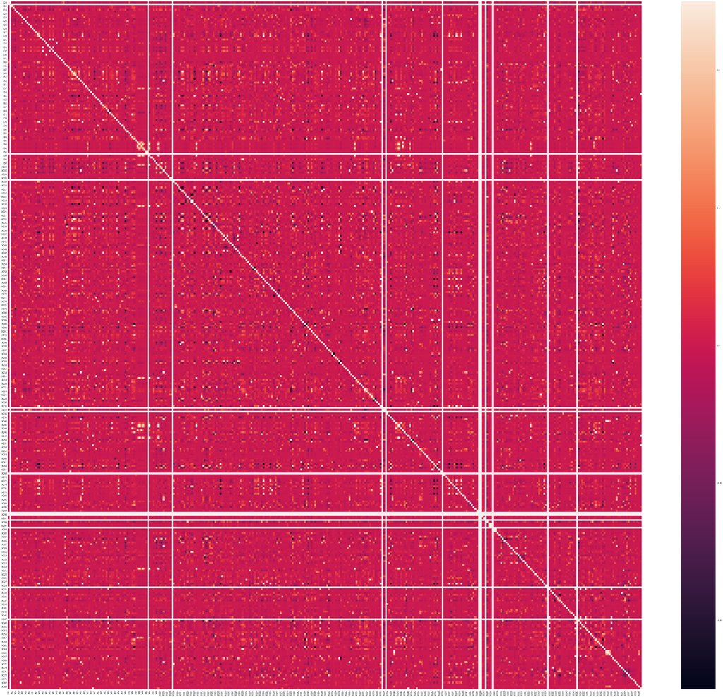

```python
plt.figure(figsize=(60,60))
sns.heatmap(train_x.corr())
```

> From above correlation plot we can observe that there are few tests, which are represented in white line, that have not been conducted for any type of vehicles. To know these few tests, lets find the correlation matrix and identify the corresponding column numbers

```python
train_x.corr()
```

|  | X10 | X11 | X12 | X13 | X14 | X15 | X16 | X17 | X18 | X19 | ... | X375 | X376 | X377 | X378 | X379 | X380 | X382 | X383 | X384 | X385 |
| --- | --- | --- | --- | --- | --- | --- | --- | --- | --- | --- | --- | --- | --- | --- | --- | --- | --- | --- | --- | --- | --- |
| X10 | 1.000000 | NaN | -0.033084 | -0.028806 | -0.100474 | -0.002532 | -0.005944 | -0.010164 | -0.010323 | -0.038610 | ... | 0.165277 | -0.028618 | -0.074244 | -0.016870 | -0.011374 | -0.010479 | -0.010164 | -0.004740 | -0.002532 | -0.004387 |
| X11 | NaN | NaN | NaN | NaN | NaN | NaN | NaN | NaN | NaN | NaN | ... | NaN | NaN | NaN | NaN | NaN | NaN | NaN | NaN | NaN | NaN |
| X12 | -0.033084 | NaN | 1.000000 | 0.214825 | -0.246513 | -0.006212 | -0.014584 | -0.024937 | -0.025327 | -0.094730 | ... | -0.107864 | -0.070214 | 0.030134 | -0.016043 | -0.027907 | -0.005566 | -0.024937 | -0.011628 | -0.006212 | -0.010765 |
| X13 | -0.028806 | NaN | 0.214825 | 1.000000 | -0.083141 | -0.005409 | -0.012698 | -0.021713 | -0.010525 | -0.082482 | ... | -0.169721 | -0.061136 | 0.357229 | -0.036040 | -0.024299 | 0.023045 | -0.021713 | -0.010125 | 0.041242 | -0.009373 |
| X14 | -0.100474 | NaN | -0.246513 | -0.083141 | 1.000000 | -0.018865 | -0.044291 | 0.012713 | -0.076916 | -0.287691 | ... | 0.118950 | 0.026496 | -0.097464 | -0.037958 | 0.103309 | 0.007743 | 0.012713 | 0.023604 | 0.025199 | 0.043667 |
| X15 | -0.002532 | NaN | -0.006212 | -0.005409 | -0.018865 | 1.000000 | -0.001116 | -0.001908 | -0.001938 | -0.007250 | ... | -0.014917 | -0.005373 | 0.032168 | -0.003168 | -0.002136 | -0.001968 | -0.001908 | -0.000890 | -0.000475 | -0.000824 |
| X16 | -0.005944 | NaN | -0.014584 | -0.012698 | -0.044291 | -0.001116 | 1.000000 | -0.004480 | -0.004550 | -0.017020 | ... | -0.025036 | -0.012615 | 0.045461 | -0.007437 | -0.005014 | -0.004619 | -0.004480 | -0.002089 | -0.001116 | -0.001934 |
| X17 | -0.010164 | NaN | -0.024937 | -0.021713 | 0.012713 | -0.001908 | -0.004480 | 1.000000 | 0.085256 | -0.029102 | ... | -0.059883 | -0.021571 | -0.059327 | -0.012716 | -0.008573 | -0.007899 | 1.000000 | -0.003572 | -0.001908 | -0.003307 |
| X18 | -0.010323 | NaN | -0.025327 | -0.010525 | -0.076916 | -0.001938 | -0.004550 | 0.085256 | 1.000000 | -0.029557 | ... | 0.037446 | -0.021908 | -0.013853 | 0.043885 | -0.008707 | -0.008022 | 0.085256 | 0.062481 | -0.001938 | -0.003359 |
| X19 | -0.038610 | NaN | -0.094730 | -0.082482 | -0.287691 | -0.007250 | -0.017020 | -0.029102 | -0.029557 | 1.000000 | ... | 0.118184 | -0.081943 | 0.051426 | -0.048305 | -0.032569 | -0.021140 | -0.029102 | -0.013571 | -0.007250 | -0.012563 |
| X20 | -0.047393 | NaN | -0.116280 | -0.043126 | -0.353137 | -0.008899 | -0.020892 | -0.027905 | -0.036281 | -0.135704 | ... | -0.025680 | -0.080123 | -0.010522 | -0.059294 | -0.025979 | -0.006485 | -0.027905 | 0.000008 | -0.008899 | -0.015421 |
| X21 | -0.005944 | NaN | -0.014584 | 0.007215 | -0.044291 | -0.001116 | -0.002620 | -0.004480 | 0.575835 | -0.017020 | ... | 0.064834 | -0.012615 | -0.024677 | -0.007437 | -0.005014 | -0.004619 | -0.004480 | -0.002089 | -0.001116 | -0.001934 |
| X22 | -0.035836 | NaN | -0.087924 | 0.226530 | -0.267021 | -0.006729 | -0.015797 | -0.017304 | -0.027434 | -0.102611 | ... | -0.084487 | -0.076055 | 0.320950 | -0.044834 | -0.030229 | -0.027849 | -0.017304 | -0.012596 | -0.006729 | -0.011660 |
| X23 | -0.016870 | NaN | -0.041391 | -0.036040 | -0.125703 | -0.003168 | -0.007437 | -0.012716 | -0.012915 | -0.048305 | ... | 0.011684 | -0.035804 | -0.040945 | -0.009369 | -0.014230 | -0.013110 | -0.012716 | -0.005930 | -0.003168 | -0.005489 |
| X24 | -0.005067 | NaN | -0.012433 | -0.010825 | -0.004686 | -0.000951 | -0.002234 | -0.003820 | -0.003879 | 0.040148 | ... | -0.029856 | -0.010755 | -0.029579 | -0.006340 | -0.004274 | -0.003938 | -0.003820 | 0.132088 | -0.000951 | -0.001649 |
| X26 | -0.008223 | NaN | -0.020175 | -0.017566 | -0.061270 | -0.001544 | -0.003625 | 0.226724 | -0.006295 | -0.023545 | ... | -0.026740 | -0.017451 | 0.039127 | -0.010288 | -0.006936 | -0.006390 | 0.226724 | -0.002890 | -0.001544 | -0.002675 |
| X27 | 0.070276 | NaN | 0.184599 | 0.110191 | 0.126863 | -0.031974 | -0.075065 | 0.059687 | -0.078274 | 0.063073 | ... | 0.139066 | -0.042846 | 0.043493 | 0.099070 | 0.051013 | -0.035398 | 0.059687 | 0.002780 | -0.031974 | 0.025765 |
| X28 | -0.021300 | NaN | -0.052259 | -0.039773 | -0.158707 | -0.003999 | -0.009389 | 0.045600 | -0.016305 | -0.060988 | ... | -0.096764 | -0.045204 | -0.083969 | 0.434454 | -0.017967 | -0.016553 | 0.045600 | -0.007486 | -0.003999 | -0.006930 |
| X29 | -0.024615 | NaN | -0.042617 | -0.052586 | -0.076904 | -0.004622 | -0.010851 | 0.412903 | 0.060829 | -0.070483 | ... | -0.145030 | -0.052242 | -0.143683 | 0.685348 | -0.020764 | -0.019130 | 0.412903 | -0.008652 | -0.004622 | -0.008009 |
| X30 | -0.007820 | NaN | -0.019185 | -0.016705 | -0.058265 | -0.001468 | -0.003447 | -0.005894 | -0.005986 | -0.022390 | ... | -0.030861 | -0.016596 | -0.045644 | -0.009783 | -0.006596 | -0.006077 | -0.005894 | -0.002748 | -0.001468 | -0.002544 |
| X31 | -0.044248 | NaN | -0.126861 | -0.095558 | -0.313459 | -0.011996 | -0.028163 | 0.068420 | 0.110549 | 0.395784 | ... | 0.029181 | -0.087163 | 0.012263 | 0.133582 | 0.085267 | 0.032050 | 0.068420 | 0.005156 | -0.011996 | -0.020787 |
| X32 | -0.012340 | NaN | -0.030276 | -0.026362 | -0.091947 | -0.002317 | -0.005440 | -0.009301 | -0.009447 | -0.035333 | ... | 0.014625 | 0.256028 | -0.072029 | -0.015438 | -0.010409 | -0.009590 | -0.009301 | -0.004337 | -0.002317 | -0.004015 |
| X33 | -0.001790 | NaN | -0.004392 | -0.003824 | 0.017817 | -0.000336 | -0.000789 | -0.001349 | -0.001370 | -0.005126 | ... | 0.022532 | -0.003799 | -0.010449 | -0.002240 | -0.001510 | -0.001391 | -0.001349 | -0.000629 | -0.000336 | -0.000582 |
| X34 | -0.008608 | NaN | -0.021119 | -0.018388 | -0.064136 | -0.001616 | -0.003794 | -0.006488 | -0.006589 | -0.024646 | ... | -0.016136 | -0.018268 | 0.046906 | -0.010769 | -0.007261 | -0.006689 | -0.006488 | -0.003025 | -0.001616 | -0.002801 |
| X35 | -0.044248 | NaN | -0.126861 | -0.095558 | -0.313459 | -0.011996 | -0.028163 | 0.068420 | 0.110549 | 0.395784 | ... | 0.029181 | -0.087163 | 0.012263 | 0.133582 | 0.085267 | 0.032050 | 0.068420 | 0.005156 | -0.011996 | -0.020787 |
| X36 | -0.007820 | NaN | -0.019185 | -0.016705 | -0.058265 | -0.001468 | -0.003447 | -0.005894 | -0.005986 | -0.022390 | ... | -0.030861 | -0.016596 | 0.007774 | -0.009783 | -0.006596 | -0.006077 | -0.005894 | -0.002748 | -0.001468 | -0.002544 |
| X37 | -0.044248 | NaN | -0.126861 | -0.095558 | -0.313459 | -0.011996 | -0.028163 | 0.068420 | 0.110549 | 0.395784 | ... | 0.029181 | -0.087163 | 0.012263 | 0.133582 | 0.085267 | 0.032050 | 0.068420 | 0.005156 | -0.011996 | -0.020787 |
| X38 | -0.021539 | NaN | 0.017543 | -0.029005 | 0.061752 | -0.004044 | -0.009495 | -0.016235 | -0.016489 | -0.061675 | ... | -0.010342 | 0.045529 | -0.034439 | -0.026948 | -0.018169 | 0.012864 | -0.016235 | -0.007571 | -0.004044 | -0.007008 |
| X39 | -0.001790 | NaN | -0.004392 | -0.003824 | 0.017817 | -0.000336 | -0.000789 | -0.001349 | -0.001370 | -0.005126 | ... | 0.022532 | -0.003799 | -0.010449 | -0.002240 | -0.001510 | -0.001391 | -0.001349 | -0.000629 | -0.000336 | -0.000582 |
| X40 | -0.003101 | NaN | -0.007609 | -0.006625 | 0.030866 | -0.000582 | -0.001367 | -0.002338 | -0.002374 | -0.008880 | ... | -0.018272 | -0.006582 | -0.018102 | -0.003880 | -0.002616 | -0.002410 | -0.002338 | -0.001090 | -0.000582 | -0.001009 |
| ... | ... | ... | ... | ... | ... | ... | ... | ... | ... | ... | ... | ... | ... | ... | ... | ... | ... | ... | ... | ... | ... |
| X355 | 0.139665 | NaN | -0.037512 | -0.192270 | 0.056933 | 0.027828 | -0.040107 | -0.000969 | 0.013581 | -0.126478 | ... | -0.058244 | 0.110225 | 0.122234 | -0.086310 | -0.016217 | 0.055039 | -0.000969 | 0.052093 | 0.005373 | -0.029603 |
| X356 | -0.048979 | NaN | -0.046559 | -0.116168 | -0.208902 | 0.018175 | 0.048728 | -0.040988 | 0.000455 | 0.110834 | ... | -0.320387 | -0.043518 | 0.618954 | -0.068033 | -0.045870 | 0.102867 | -0.040988 | 0.071977 | -0.010210 | -0.017693 |
| X357 | -0.004005 | NaN | -0.009826 | -0.008555 | 0.039858 | -0.000752 | -0.001765 | -0.003019 | -0.003066 | -0.011467 | ... | -0.023595 | -0.008499 | -0.023376 | -0.005010 | -0.003378 | -0.003112 | -0.003019 | -0.001408 | -0.000752 | -0.001303 |
| X358 | -0.100230 | NaN | 0.085827 | 0.283290 | 0.161773 | -0.018820 | 0.002857 | 0.046107 | 0.026745 | -0.264534 | ... | 0.026843 | -0.165170 | -0.134136 | 0.131178 | -0.064744 | -0.018867 | 0.046107 | 0.011922 | 0.003220 | 0.043773 |
| X359 | -0.021057 | NaN | -0.051664 | 0.007134 | 0.168556 | -0.003954 | -0.009282 | 0.155503 | 0.060598 | -0.060294 | ... | 0.026934 | -0.033041 | -0.061724 | -0.026345 | 0.010134 | -0.016364 | 0.155503 | -0.007401 | -0.003954 | -0.006851 |
| X360 | -0.033422 | NaN | 0.236848 | 0.341697 | 0.005676 | -0.006276 | 0.002774 | -0.025192 | 0.045356 | -0.095699 | ... | 0.015984 | -0.044002 | 0.076279 | -0.041814 | -0.009767 | -0.006002 | -0.025192 | -0.011747 | -0.006276 | -0.010875 |
| X361 | 0.021777 | NaN | -0.210335 | 0.046522 | 0.085403 | 0.004089 | 0.009600 | 0.016414 | 0.001802 | 0.053595 | ... | 0.108607 | 0.046218 | 0.127114 | 0.027245 | 0.018370 | 0.016924 | 0.016414 | 0.007654 | 0.004089 | 0.007086 |
| X362 | 0.111496 | NaN | -0.083772 | -0.258361 | -0.108226 | -0.000887 | 0.002576 | -0.091158 | -0.076407 | 0.319252 | ... | 0.033409 | 0.019659 | 0.216654 | -0.151307 | 0.074444 | -0.014295 | -0.091158 | 0.027518 | -0.000887 | -0.039350 |
| X363 | 0.056725 | NaN | 0.093726 | 0.056781 | 0.227999 | 0.012459 | -0.078781 | 0.024615 | -0.024248 | -0.430832 | ... | -0.022109 | 0.000759 | -0.035467 | 0.059754 | -0.080466 | 0.039242 | 0.024615 | 0.023322 | 0.012459 | 0.021589 |
| X364 | -0.006209 | NaN | -0.015234 | 0.005803 | 0.061799 | -0.001166 | -0.002737 | -0.004680 | -0.004753 | -0.017779 | ... | -0.017460 | -0.013178 | -0.026649 | -0.007768 | -0.005238 | -0.004825 | -0.004680 | -0.002182 | 0.407763 | -0.002020 |
| X365 | -0.006209 | NaN | -0.015234 | 0.005803 | 0.061799 | -0.001166 | -0.002737 | -0.004680 | -0.004753 | -0.017779 | ... | -0.017460 | -0.013178 | -0.026649 | -0.007768 | -0.005238 | -0.004825 | -0.004680 | -0.002182 | 0.407763 | -0.002020 |
| X366 | -0.004005 | NaN | -0.009826 | 0.020960 | 0.039858 | -0.000752 | -0.001765 | -0.003019 | -0.003066 | -0.011467 | ... | 0.006006 | -0.008499 | -0.008525 | -0.005010 | -0.003378 | -0.003112 | -0.003019 | -0.001408 | 0.632230 | -0.001303 |
| X367 | -0.027139 | NaN | -0.066587 | -0.057978 | 0.226781 | -0.005096 | 0.030034 | -0.020456 | -0.020776 | -0.074129 | ... | -0.159900 | -0.057598 | 0.340191 | -0.033954 | -0.022893 | -0.009114 | -0.020456 | -0.009539 | -0.005096 | -0.008830 |
| X368 | -0.030039 | NaN | -0.062547 | -0.047400 | -0.087187 | -0.005640 | -0.013242 | 0.022482 | -0.022996 | 0.205271 | ... | -0.107600 | -0.059536 | 0.098935 | -0.010034 | -0.025339 | 0.009496 | 0.022482 | 0.013489 | -0.005640 | -0.009774 |
| X369 | -0.002532 | NaN | -0.006212 | -0.005409 | -0.018865 | -0.000475 | -0.001116 | -0.001908 | -0.001938 | -0.007250 | ... | -0.014917 | -0.005373 | -0.014779 | -0.003168 | -0.002136 | 0.241611 | -0.001908 | -0.000890 | -0.000475 | -0.000824 |
| X370 | -0.009503 | NaN | -0.023315 | -0.020301 | -0.070807 | -0.001784 | -0.004189 | -0.007163 | -0.007275 | -0.027210 | ... | -0.055989 | 0.332060 | -0.055469 | -0.011889 | -0.008016 | -0.007385 | -0.007163 | -0.003340 | -0.001784 | -0.003092 |
| X371 | -0.013964 | NaN | -0.034261 | -0.029832 | -0.091899 | -0.002622 | -0.006156 | -0.010526 | -0.010690 | -0.039984 | ... | -0.082275 | -0.029636 | -0.081511 | -0.017471 | -0.011779 | -0.010852 | -0.010526 | -0.004908 | -0.002622 | -0.004544 |
| X372 | -0.002532 | NaN | -0.006212 | -0.005409 | -0.018865 | -0.000475 | -0.001116 | -0.001908 | -0.001938 | -0.007250 | ... | -0.014917 | -0.005373 | -0.014779 | -0.003168 | -0.002136 | -0.001968 | -0.001908 | -0.000890 | -0.000475 | -0.000824 |
| X373 | -0.016266 | NaN | 0.176659 | -0.034749 | -0.054797 | -0.003054 | -0.007170 | -0.012261 | -0.012452 | -0.023471 | ... | -0.095837 | -0.034522 | -0.094947 | -0.020351 | -0.013721 | -0.012641 | -0.012261 | -0.005717 | -0.003054 | -0.005293 |
| X374 | -0.062993 | NaN | 0.097125 | -0.134572 | -0.008845 | -0.011828 | -0.005563 | -0.047481 | -0.035369 | -0.093279 | ... | -0.371145 | -0.133691 | -0.367698 | -0.078811 | -0.053137 | -0.048954 | -0.047481 | -0.022141 | 0.014182 | -0.020496 |
| X375 | 0.165277 | NaN | -0.107864 | -0.169721 | 0.118950 | -0.014917 | -0.025036 | -0.059883 | 0.037446 | 0.118184 | ... | 1.000000 | -0.168611 | -0.463738 | -0.099396 | -0.067016 | -0.061741 | -0.059883 | -0.015413 | -0.014917 | 0.055225 |
| X376 | -0.028618 | NaN | -0.070214 | -0.061136 | 0.026496 | -0.005373 | -0.012615 | -0.021571 | -0.021908 | -0.081943 | ... | -0.168611 | 1.000000 | -0.167045 | -0.035804 | -0.024140 | -0.022240 | -0.021571 | -0.010059 | -0.005373 | -0.009311 |
| X377 | -0.074244 | NaN | 0.030134 | 0.357229 | -0.097464 | 0.032168 | 0.045461 | -0.059327 | -0.013853 | 0.051426 | ... | -0.463738 | -0.167045 | 1.000000 | -0.098473 | -0.066393 | -0.061168 | -0.059327 | 0.035107 | 0.008694 | -0.025610 |
| X378 | -0.016870 | NaN | -0.016043 | -0.036040 | -0.037958 | -0.003168 | -0.007437 | -0.012716 | 0.043885 | -0.048305 | ... | -0.099396 | -0.035804 | -0.098473 | 1.000000 | -0.014230 | -0.013110 | -0.012716 | -0.005930 | -0.003168 | -0.005489 |
| X379 | -0.011374 | NaN | -0.027907 | -0.024299 | 0.103309 | -0.002136 | -0.005014 | -0.008573 | -0.008707 | -0.032569 | ... | -0.067016 | -0.024140 | -0.066393 | -0.014230 | 1.000000 | -0.008839 | -0.008573 | -0.003998 | -0.002136 | -0.003701 |
| X380 | -0.010479 | NaN | -0.005566 | 0.023045 | 0.007743 | -0.001968 | -0.004619 | -0.007899 | -0.008022 | -0.021140 | ... | -0.061741 | -0.022240 | -0.061168 | -0.013110 | -0.008839 | 1.000000 | -0.007899 | -0.003683 | -0.001968 | -0.003410 |
| X382 | -0.010164 | NaN | -0.024937 | -0.021713 | 0.012713 | -0.001908 | -0.004480 | 1.000000 | 0.085256 | -0.029102 | ... | -0.059883 | -0.021571 | -0.059327 | -0.012716 | -0.008573 | -0.007899 | 1.000000 | -0.003572 | -0.001908 | -0.003307 |
| X383 | -0.004740 | NaN | -0.011628 | -0.010125 | 0.023604 | -0.000890 | -0.002089 | -0.003572 | 0.062481 | -0.013571 | ... | -0.015413 | -0.010059 | 0.035107 | -0.005930 | -0.003998 | -0.003683 | -0.003572 | 1.000000 | -0.000890 | -0.001542 |
| X384 | -0.002532 | NaN | -0.006212 | 0.041242 | 0.025199 | -0.000475 | -0.001116 | -0.001908 | -0.001938 | -0.007250 | ... | -0.014917 | -0.005373 | 0.008694 | -0.003168 | -0.002136 | -0.001968 | -0.001908 | -0.000890 | 1.000000 | -0.000824 |
| X385 | -0.004387 | NaN | -0.010765 | -0.009373 | 0.043667 | -0.000824 | -0.001934 | -0.003307 | -0.003359 | -0.012563 | ... | 0.055225 | -0.009311 | -0.025610 | -0.005489 | -0.003701 | -0.003410 | -0.003307 | -0.001542 | -0.000824 | 1.000000 |

368 rows × 368 columns

> We have 12 features which only have a single/unique (Zero Variance) value in them — these are pretty useless for supervised algorithms, and should probably be dropped.

### Shape of train_x before dropping above identified columns

```python
print('Before: Train dataset shape = ', train_x.shape)
train_x.drop(['X11','X93','X107', 'X233', 'X235', 'X268', 'X289', 'X290', 'X293','X297', 'X330', 'X347'],axis=1, inplace=True)
print('After: Train dataset shape = ', train_x.shape)
print ('')
print('Before: Test dataset shape = ', test_x.shape)
test_x.drop(['X11','X93','X107', 'X233', 'X235', 'X268', 'X289', 'X290', 'X293','X297', 'X330', 'X347'],axis=1, inplace=True)
print('After: Test dataset shape = ', test_x.shape)
```

```
Before: Train dataset shape =  (4209, 376)
After: Train dataset shape =  (4209, 364)

Before: Test dataset shape =  (4209, 376)
After: Test dataset shape =  (4209, 364)
```

## 4. Data Preprocessing

### One Hot Encoding:

As mentioned earlier, we have 8 categorical columns and 369 integer values. These 369 integer values are already in '0' and '1' format, so we will convert other 8 categorical columns into one hot encoded columns to have entire train data in same format.

```python
def one_hot(train_data,test_data,columns):

    for i,column in enumerate(columns):
        Xtrain = train_data[str(column)].T
        Xtest = test_data[str(column)].T

        # train_df
        lb=preprocessing.LabelBinarizer()
        lb.fit(Xtrain)
        X_classes = len(lb.classes_)
        Xenc = lb.transform(Xtrain)
        Xtrain_enc = pd.DataFrame(data = Xenc, columns = lb.classes_)
        train_data.drop([str(column)], axis =1, inplace=True)

        # test_df
        Xenc = lb.transform(Xtest)
        Xtest_enc = pd.DataFrame(data = Xenc, columns = lb.classes_)
        test_data.drop([str(column)], axis =1, inplace=True)

        print('Number of classes in '+str(column)+ ' = '+ str(X_classes))
        train_data = pd.concat((train_data,Xtrain_enc),axis=1)
        test_data = pd.concat((test_data,Xtest_enc),axis=1)
    return train_data,test_data
```

```python
train_data , test_data = one_hot(train_x,test_x,['X0', 'X1', 'X2', 'X3', 'X4', 'X5', 'X6', 'X8'])
```

```
Number of classes in X0 = 47
Number of classes in X1 = 27
Number of classes in X2 = 44
Number of classes in X3 = 7
Number of classes in X4 = 4
Number of classes in X5 = 29
Number of classes in X6 = 12
Number of classes in X8 = 25
```

### Label Encoding :

```python
from sklearn.preprocessing import LabelEncoder

for c in train_df.columns:
    if train_df[c].dtype == 'object':
        lbl = LabelEncoder()
        lbl.fit(list(train_df[c].values) + list(test_df[c].values))# Fit label encoder
        train_x[c] = lbl.transform(list(train_df[c].values))# Transform labels to normalized encoding.
        test_x[c] = lbl.transform(list(test_df[c].values))# Transform labels to normalized encoding.
```

## 5. Feature Selection

### Principal Component Analysis (PCA)

```python
pca = PCA(random_state=seed)
pca.fit(train_x)
pca_train = pca.transform(train_x)
pca_test = pca.transform(test_x)
```

```python
X = pca_train
y = train_y
X.shape,y.shape
```

```
((4209, 364), (4209,))
```

## PERFORMING A TRAIN-TEST SPLIT

```python
from sklearn.model_selection import train_test_split
```

```python
x=train_x
y=train_y
x_train,x_test,y_train,y_test = train_test_split(x,y,test_size=0.2,random_state=101)
x_train.head()
```

|  | X1 | X2 | X3 | X4 | X5 | X6 | X8 | X10 | X12 | X13 | ... | X376 | X377 | X378 | X379 | X380 | X382 | X383 | X384 | X385 | X0 |
| --- | --- | --- | --- | --- | --- | --- | --- | --- | --- | --- | --- | --- | --- | --- | --- | --- | --- | --- | --- | --- | --- |
| 4057 | 3 | 37 | 0 | 3 | 29 | 7 | 5 | 0 | 0 | 0 | ... | 0 | 1 | 0 | 0 | 0 | 0 | 0 | 0 | 0 | 46 |
| 3986 | 20 | 19 | 2 | 3 | 29 | 6 | 17 | 0 | 0 | 0 | ... | 0 | 0 | 0 | 0 | 0 | 0 | 0 | 0 | 0 | 49 |
| 3254 | 20 | 19 | 2 | 3 | 25 | 8 | 3 | 0 | 0 | 0 | ... | 0 | 0 | 0 | 0 | 0 | 0 | 0 | 0 | 0 | 49 |
| 2421 | 15 | 19 | 2 | 3 | 20 | 9 | 2 | 0 | 0 | 0 | ... | 0 | 0 | 0 | 0 | 0 | 1 | 0 | 0 | 0 | 24 |
| 1466 | 21 | 38 | 2 | 3 | 3 | 11 | 17 | 0 | 0 | 0 | ... | 0 | 0 | 0 | 0 | 0 | 1 | 0 | 0 | 0 | 24 |

5 rows × 364 columns

```python
x_test.head()
```

|  | X1 | X2 | X3 | X4 | X5 | X6 | X8 | X10 | X12 | X13 | ... | X376 | X377 | X378 | X379 | X380 | X382 | X383 | X384 | X385 | X0 |
| --- | --- | --- | --- | --- | --- | --- | --- | --- | --- | --- | --- | --- | --- | --- | --- | --- | --- | --- | --- | --- | --- |
| 1453 | 7 | 19 | 3 | 3 | 3 | 3 | 15 | 0 | 0 | 0 | ... | 0 | 0 | 0 | 0 | 1 | 0 | 0 | 0 | 0 | 14 |
| 82 | 13 | 19 | 5 | 3 | 16 | 6 | 0 | 0 | 0 | 0 | ... | 0 | 0 | 0 | 0 | 0 | 0 | 0 | 0 | 0 | 41 |
| 4013 | 13 | 19 | 5 | 3 | 29 | 6 | 8 | 0 | 0 | 0 | ... | 0 | 0 | 0 | 0 | 0 | 0 | 0 | 0 | 0 | 41 |
| 2226 | 1 | 5 | 2 | 3 | 17 | 6 | 22 | 0 | 0 | 0 | ... | 0 | 0 | 0 | 0 | 0 | 0 | 0 | 0 | 0 | 46 |
| 3107 | 23 | 11 | 5 | 3 | 23 | 6 | 1 | 0 | 1 | 0 | ... | 0 | 0 | 0 | 0 | 0 | 0 | 0 | 0 | 0 | 10 |

5 rows × 364 columns

```python
x_train.shape
```

```
(3367, 364)
```

```python
x_test.shape
```

```
(842, 364)
```

### XGBoost model

```python
import warnings
warnings.simplefilter(action='ignore', category=FutureWarning)
import xgboost as xgb

##Prepare dict of params for xgboost model.
xgb_params = {
     'n_trees': 40,
    'eta': 0.04,

    'subsample': 0.8,
    'objective': 'reg:linear',
    'eval_metric': 'rmse',
    'max_depth':'4',
    'silent': 1}


##Creating DMatrices for Xgboost training
dtrain = xgb.DMatrix(x_train, y_train)
dtest = xgb.DMatrix(x_test)




model = xgb.XGBRegressor()
model.fit(x_train,y_train)

print (model)



##xgboost, cross-validation
cv_result = xgb.cv(xgb_params,dtrain,num_boost_round=150,verbose_eval=50,maximize=True,show_stdv=False)

num_boost_rounds = len(cv_result)
print(num_boost_rounds)

#Train model
model = xgb.train(dict(xgb_params, silent=0), dtrain, num_boost_round=num_boost_rounds)
```

```
[12:01:48] WARNING: src/objective/regression_obj.cu:152: reg:linear is now deprecated in favor of reg:squarederror.
XGBRegressor(base_score=0.5, booster='gbtree', colsample_bylevel=1,
             colsample_bynode=1, colsample_bytree=1, gamma=0,
             importance_type='gain', learning_rate=0.1, max_delta_step=0,
             max_depth=3, min_child_weight=1, missing=None, n_estimators=100,
             n_jobs=1, nthread=None, objective='reg:linear', random_state=0,
             reg_alpha=0, reg_lambda=1, scale_pos_weight=1, seed=None,
             silent=None, subsample=1, verbosity=1)
150
[12:02:01] WARNING: src/objective/regression_obj.cu:152: reg:linear is now deprecated in favor of reg:squarederror.
```

## making prediction

```python
preds =model.predict(dtest)
preds
```

[output not shown]

[output cut: 114 more lines]

```
        91.100945, 103.13092 , 106.37022 ,  93.5786  , 103.54104 ,
       111.752464,  93.82687 ,  77.61675 ,  96.11008 , 112.46115 ,
       109.86833 , 113.69217 , 118.13349 ,  93.36669 ,  93.91355 ,
       111.865585,  95.22532 , 112.82809 , 116.91422 ,  94.2134  ,
       103.79924 ,  78.139694, 110.92647 , 112.43339 ,  94.058655,
        94.1606  , 105.76408 ,  93.31639 , 110.68208 , 111.53852 ,
        91.90018 , 112.07633 , 111.7756  , 112.15334 , 112.68492 ,
       109.42026 , 103.18555 , 104.0015  ,  78.732376,  93.99346 ,
        94.802536,  93.18753 , 103.148605,  93.1478  ,  94.562454,
        94.450745, 112.43228 , 111.72584 ,  95.27584 , 112.20612 ,
        94.57838 ,  94.06542 , 116.269455,  93.85546 ,  94.51364 ,
        92.99445 ,  93.89742 ,  94.81324 ,  78.52035 ,  93.55213 ,
        93.4345  , 112.09025 , 115.29221 , 114.69661 ,  94.14005 ,
       103.659966,  94.48501 ,  94.677574, 111.50203 ,  93.62055 ,
        93.23176 , 111.88356 ], dtype=float32)
```